# Risk Factor Analysis

## Outcome Variable

**Outcome Variable:** wast_rec90d

## Predictor Variables

**Intervention Variable:** fhtcm

**Adjustment Set:**

unadjusted

## Stratifying Variables

The analysis was stratified on these variable(s):

- agecat
- studyid
- country

## Data Summary

| agecat | studyid | country | fhtcm | wast_rec90d | n_cell | n |
| --- | --- | --- | --- | --- | --- | --- |
| 0-24 months | ki1000304b-SAS-CompFeed | INDIA | >=167 cm | 0 | 34 | 117 |
| 0-24 months | ki1000304b-SAS-CompFeed | INDIA | >=167 cm | 1 | 16 | 117 |
| 0-24 months | ki1000304b-SAS-CompFeed | INDIA | <162 cm | 0 | 19 | 117 |
| 0-24 months | ki1000304b-SAS-CompFeed | INDIA | <162 cm | 1 | 9 | 117 |
| 0-24 months | ki1000304b-SAS-CompFeed | INDIA | [162-167) cm | 0 | 27 | 117 |
| 0-24 months | ki1000304b-SAS-CompFeed | INDIA | [162-167) cm | 1 | 12 | 117 |
| 0-24 months | ki1000304b-SAS-FoodSuppl | INDIA | >=167 cm | 0 | 13 | 60 |
| 0-24 months | ki1000304b-SAS-FoodSuppl | INDIA | >=167 cm | 1 | 1 | 60 |
| 0-24 months | ki1000304b-SAS-FoodSuppl | INDIA | <162 cm | 0 | 23 | 60 |
| 0-24 months | ki1000304b-SAS-FoodSuppl | INDIA | <162 cm | 1 | 1 | 60 |
| 0-24 months | ki1000304b-SAS-FoodSuppl | INDIA | [162-167) cm | 0 | 20 | 60 |
| 0-24 months | ki1000304b-SAS-FoodSuppl | INDIA | [162-167) cm | 1 | 2 | 60 |
| 0-24 months | ki1101329-Keneba | GAMBIA | >=167 cm | 0 | 324 | 1086 |
| 0-24 months | ki1101329-Keneba | GAMBIA | >=167 cm | 1 | 380 | 1086 |
| 0-24 months | ki1101329-Keneba | GAMBIA | <162 cm | 0 | 39 | 1086 |
| 0-24 months | ki1101329-Keneba | GAMBIA | <162 cm | 1 | 41 | 1086 |
| 0-24 months | ki1101329-Keneba | GAMBIA | [162-167) cm | 0 | 129 | 1086 |
| 0-24 months | ki1101329-Keneba | GAMBIA | [162-167) cm | 1 | 173 | 1086 |
| 0-24 months | ki1119695-PROBIT | BELARUS | >=167 cm | 0 | 216 | 1830 |
| 0-24 months | ki1119695-PROBIT | BELARUS | >=167 cm | 1 | 1497 | 1830 |
| 0-24 months | ki1119695-PROBIT | BELARUS | <162 cm | 0 | 3 | 1830 |
| 0-24 months | ki1119695-PROBIT | BELARUS | <162 cm | 1 | 24 | 1830 |
| 0-24 months | ki1119695-PROBIT | BELARUS | [162-167) cm | 0 | 3 | 1830 |
| 0-24 months | ki1119695-PROBIT | BELARUS | [162-167) cm | 1 | 87 | 1830 |
| 0-24 months | ki1135781-COHORTS | GUATEMALA | >=167 cm | 0 | 6 | 81 |
| 0-24 months | ki1135781-COHORTS | GUATEMALA | >=167 cm | 1 | 3 | 81 |
| 0-24 months | ki1135781-COHORTS | GUATEMALA | <162 cm | 0 | 43 | 81 |
| 0-24 months | ki1135781-COHORTS | GUATEMALA | <162 cm | 1 | 6 | 81 |
| 0-24 months | ki1135781-COHORTS | GUATEMALA | [162-167) cm | 0 | 16 | 81 |
| 0-24 months | ki1135781-COHORTS | GUATEMALA | [162-167) cm | 1 | 7 | 81 |

[output cut: 60 more lines]

The following strata were considered:

- agecat: 0-24 months, studyid: ki1000304b-SAS-CompFeed, country: INDIA
- agecat: 0-24 months, studyid: ki1000304b-SAS-FoodSuppl, country: INDIA
- agecat: 0-24 months, studyid: ki1101329-Keneba, country: GAMBIA
- agecat: 0-24 months, studyid: ki1119695-PROBIT, country: BELARUS
- agecat: 0-24 months, studyid: ki1135781-COHORTS, country: GUATEMALA
- agecat: 0-6 months, studyid: ki1000304b-SAS-CompFeed, country: INDIA
- agecat: 0-6 months, studyid: ki1000304b-SAS-FoodSuppl, country: INDIA
- agecat: 0-6 months, studyid: ki1101329-Keneba, country: GAMBIA
- agecat: 0-6 months, studyid: ki1119695-PROBIT, country: BELARUS
- agecat: 0-6 months, studyid: ki1135781-COHORTS, country: GUATEMALA
- agecat: 6-24 months, studyid: ki1000304b-SAS-CompFeed, country: INDIA
- agecat: 6-24 months, studyid: ki1000304b-SAS-FoodSuppl, country: INDIA
- agecat: 6-24 months, studyid: ki1101329-Keneba, country: GAMBIA
- agecat: 6-24 months, studyid: ki1119695-PROBIT, country: BELARUS
- agecat: 6-24 months, studyid: ki1135781-COHORTS, country: GUATEMALA

### Dropped Strata

Some strata were dropped due to rare outcomes:

- agecat: 0-24 months, studyid: ki1000304b-SAS-FoodSuppl, country: INDIA
- agecat: 0-24 months, studyid: ki1119695-PROBIT, country: BELARUS
- agecat: 0-24 months, studyid: ki1135781-COHORTS, country: GUATEMALA
- agecat: 0-6 months, studyid: ki1000304b-SAS-FoodSuppl, country: INDIA
- agecat: 0-6 months, studyid: ki1119695-PROBIT, country: BELARUS
- agecat: 0-6 months, studyid: ki1135781-COHORTS, country: GUATEMALA
- agecat: 6-24 months, studyid: ki1000304b-SAS-CompFeed, country: INDIA
- agecat: 6-24 months, studyid: ki1000304b-SAS-FoodSuppl, country: INDIA
- agecat: 6-24 months, studyid: ki1119695-PROBIT, country: BELARUS
- agecat: 6-24 months, studyid: ki1135781-COHORTS, country: GUATEMALA

## Methods Detail

We’re interested in the causal parameters $E[Y_a]$ for all values of $a \in \mathcal{A}$. These parameters represent the mean outcome if, possibly contrary to fact, we intervened to set all units to have $A=a$. Under the randomization and positivity assumptions, these are identified by the statistical parameters $\psi_a=E_W[E_{Y|A,W}(Y|A=a,W)]$. In addition, we’re interested in the mean of $Y$, $E[Y]$ under no intervention (the observed mean). We will estimate these parameters by using SuperLearner to fit the relevant likelihood factors – $E_{Y|A,W}(Y|A=a,W)$ and $p(A=a|W)$, and then updating our likelihood fit using a joint TMLE.

For unadjusted analyses ($W=\{\}$), initial likelihoods were estimated using Lrnr_glm to estimate the simple $E(Y|A)$ and Lrnr_mean to estimate $p(A)$. For adjusted analyses, a small library containing Lrnr_glmnet, Lrnr_xgboost, and Lrnr_mean was used.

Having estimated these parameters, we will then use the delta method to estimate relative risks and attributable risks relative to a prespecified baseline level of $A$.

# Results Detail

## Results Plots

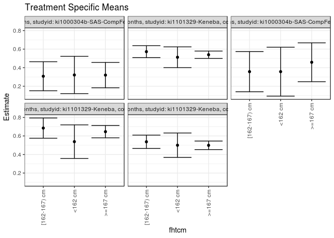

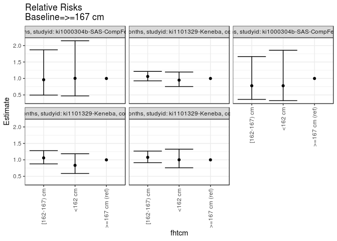

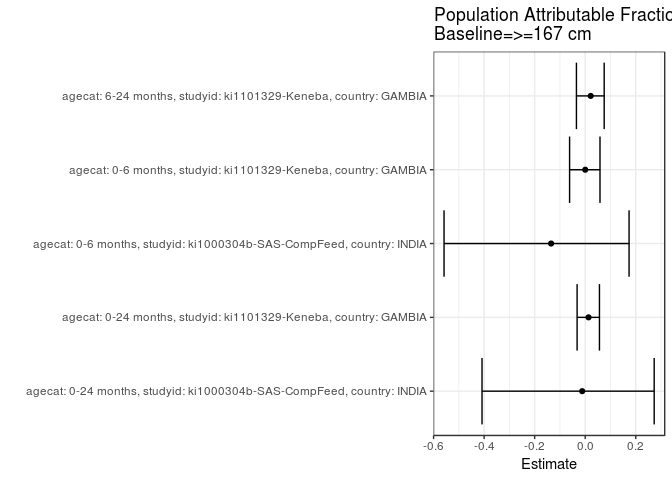

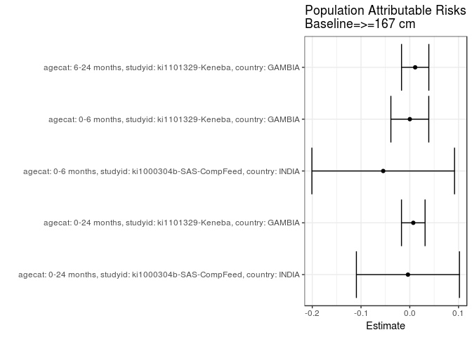

## Results Table

### Parameter: TSM

| agecat | studyid | country | intervention_level | baseline_level | estimate | ci_lower | ci_upper |
| --- | --- | --- | --- | --- | --- | --- | --- |
| 0-24 months | ki1000304b-SAS-CompFeed | INDIA | >=167 cm | NA | 0.3200000 | 0.1831508 | 0.4568492 |
| 0-24 months | ki1000304b-SAS-CompFeed | INDIA | <162 cm | NA | 0.3214286 | 0.1201781 | 0.5226791 |
| 0-24 months | ki1000304b-SAS-CompFeed | INDIA | [162-167) cm | NA | 0.3076923 | 0.1512241 | 0.4641605 |
| 0-24 months | ki1101329-Keneba | GAMBIA | >=167 cm | NA | 0.5397727 | 0.5002388 | 0.5793066 |
| 0-24 months | ki1101329-Keneba | GAMBIA | <162 cm | NA | 0.5125000 | 0.4003549 | 0.6246451 |
| 0-24 months | ki1101329-Keneba | GAMBIA | [162-167) cm | NA | 0.5728477 | 0.5082199 | 0.6374754 |
| 0-6 months | ki1000304b-SAS-CompFeed | INDIA | >=167 cm | NA | 0.4583333 | 0.2489127 | 0.6677540 |
| 0-6 months | ki1000304b-SAS-CompFeed | INDIA | <162 cm | NA | 0.3571429 | 0.0934596 | 0.6208261 |
| 0-6 months | ki1000304b-SAS-CompFeed | INDIA | [162-167) cm | NA | 0.3571429 | 0.1403954 | 0.5738903 |
| 0-6 months | ki1101329-Keneba | GAMBIA | >=167 cm | NA | 0.6461538 | 0.5797019 | 0.7126058 |
| 0-6 months | ki1101329-Keneba | GAMBIA | <162 cm | NA | 0.5384615 | 0.3573826 | 0.7195405 |
| 0-6 months | ki1101329-Keneba | GAMBIA | [162-167) cm | NA | 0.6849315 | 0.5759682 | 0.7938948 |
| 6-24 months | ki1101329-Keneba | GAMBIA | >=167 cm | NA | 0.4990177 | 0.4529680 | 0.5450673 |
| 6-24 months | ki1101329-Keneba | GAMBIA | <162 cm | NA | 0.5000000 | 0.3685451 | 0.6314549 |
| 6-24 months | ki1101329-Keneba | GAMBIA | [162-167) cm | NA | 0.5371179 | 0.4652021 | 0.6090337 |

### Parameter: E(Y)

| agecat | studyid | country | intervention_level | baseline_level | estimate | ci_lower | ci_upper |
| --- | --- | --- | --- | --- | --- | --- | --- |
| 0-24 months | ki1000304b-SAS-CompFeed | INDIA | NA | NA | 0.3162393 | 0.2243340 | 0.4081446 |
| 0-24 months | ki1101329-Keneba | GAMBIA | NA | NA | 0.5469613 | 0.5145713 | 0.5793513 |
| 0-6 months | ki1000304b-SAS-CompFeed | INDIA | NA | NA | 0.4038462 | 0.2695653 | 0.5381270 |
| 0-6 months | ki1101329-Keneba | GAMBIA | NA | NA | 0.6462585 | 0.5919377 | 0.7005793 |
| 6-24 months | ki1101329-Keneba | GAMBIA | NA | NA | 0.5101010 | 0.4728139 | 0.5473881 |

### Parameter: RR

| agecat | studyid | country | intervention_level | baseline_level | estimate | ci_lower | ci_upper |
| --- | --- | --- | --- | --- | --- | --- | --- |
| 0-24 months | ki1000304b-SAS-CompFeed | INDIA | >=167 cm | >=167 cm | 1.0000000 | 1.0000000 | 1.000000 |
| 0-24 months | ki1000304b-SAS-CompFeed | INDIA | <162 cm | >=167 cm | 1.0044643 | 0.4705244 | 2.144306 |
| 0-24 months | ki1000304b-SAS-CompFeed | INDIA | [162-167) cm | >=167 cm | 0.9615385 | 0.4946832 | 1.868987 |
| 0-24 months | ki1101329-Keneba | GAMBIA | >=167 cm | >=167 cm | 1.0000000 | 1.0000000 | 1.000000 |
| 0-24 months | ki1101329-Keneba | GAMBIA | <162 cm | >=167 cm | 0.9494737 | 0.7538220 | 1.195906 |
| 0-24 months | ki1101329-Keneba | GAMBIA | [162-167) cm | >=167 cm | 1.0612757 | 0.9276968 | 1.214089 |
| 0-6 months | ki1000304b-SAS-CompFeed | INDIA | >=167 cm | >=167 cm | 1.0000000 | 1.0000000 | 1.000000 |
| 0-6 months | ki1000304b-SAS-CompFeed | INDIA | <162 cm | >=167 cm | 0.7792208 | 0.3270234 | 1.856702 |
| 0-6 months | ki1000304b-SAS-CompFeed | INDIA | [162-167) cm | >=167 cm | 0.7792208 | 0.3645371 | 1.665633 |
| 0-6 months | ki1101329-Keneba | GAMBIA | >=167 cm | >=167 cm | 1.0000000 | 1.0000000 | 1.000000 |
| 0-6 months | ki1101329-Keneba | GAMBIA | <162 cm | >=167 cm | 0.8333333 | 0.5862619 | 1.184529 |
| 0-6 months | ki1101329-Keneba | GAMBIA | [162-167) cm | >=167 cm | 1.0600130 | 0.8770763 | 1.281106 |
| 6-24 months | ki1101329-Keneba | GAMBIA | >=167 cm | >=167 cm | 1.0000000 | 1.0000000 | 1.000000 |
| 6-24 months | ki1101329-Keneba | GAMBIA | <162 cm | >=167 cm | 1.0019685 | 0.7582760 | 1.323978 |
| 6-24 months | ki1101329-Keneba | GAMBIA | [162-167) cm | >=167 cm | 1.0763504 | 0.9147876 | 1.266447 |

### Parameter: PAR

| agecat | studyid | country | intervention_level | baseline_level | estimate | ci_lower | ci_upper |
| --- | --- | --- | --- | --- | --- | --- | --- |
| 0-24 months | ki1000304b-SAS-CompFeed | INDIA | >=167 cm | NA | -0.0037607 | -0.1094856 | 0.1019642 |
| 0-24 months | ki1101329-Keneba | GAMBIA | >=167 cm | NA | 0.0071886 | -0.0170022 | 0.0313794 |
| 0-6 months | ki1000304b-SAS-CompFeed | INDIA | >=167 cm | NA | -0.0544872 | -0.2007915 | 0.0918171 |
| 0-6 months | ki1101329-Keneba | GAMBIA | >=167 cm | NA | 0.0001047 | -0.0387471 | 0.0389564 |
| 6-24 months | ki1101329-Keneba | GAMBIA | >=167 cm | NA | 0.0110833 | -0.0169159 | 0.0390826 |

### Parameter: PAF

| agecat | studyid | country | intervention_level | baseline_level | estimate | ci_lower | ci_upper |
| --- | --- | --- | --- | --- | --- | --- | --- |
| 0-24 months | ki1000304b-SAS-CompFeed | INDIA | >=167 cm | NA | -0.0118919 | -0.4083057 | 0.2729382 |
| 0-24 months | ki1101329-Keneba | GAMBIA | >=167 cm | NA | 0.0131428 | -0.0320609 | 0.0563666 |
| 0-6 months | ki1000304b-SAS-CompFeed | INDIA | >=167 cm | NA | -0.1349206 | -0.5585656 | 0.1735704 |
| 0-6 months | ki1101329-Keneba | GAMBIA | >=167 cm | NA | 0.0001619 | -0.0618000 | 0.0585080 |
| 6-24 months | ki1101329-Keneba | GAMBIA | >=167 cm | NA | 0.0217277 | -0.0347121 | 0.0750889 |